# When Does the Central Limit Theorem Work?

A Monte Carlo investigation of eleven probability distributions to examine the sampling distribution of the mean and estimate the sample size at which it becomes approximately normal.

Author

Chau Nguyen

Published

October 12, 2026

# 1 Executive Summary

## 1.1 Central Limit Theorem

Let $X_1, X_2, ..., X_n$ be a random sample from a distribution. The Central Limit Theorem (CLT) states that if the sample size $n$ is “sufficiently large,” then the sampling distribution of the sample mean $\bar{X}$ follows an approximate normal distribution with $E[\bar{X}] = \mu$ and $Var(\bar{X}) = \sigma^2/n$.

$$Z_n = \frac{\bar{X}_n - \mu}{\sigma/\sqrt{n}} \;\xrightarrow{d}\; N(\mu , \frac{\sigma}{\sqrt{n}})$$

The sample size $n$ to which the sampling distribution yields adequately “normal” depends on the shape of the population distribution

Fast

n ≤ 12

Symmetrical, light-tailed

Distributions: Normal, Uniform, Die, Binomial Large, R Nonidentical

Moderate

n ≈ 30

Highly discrete or skewed

Distributions: Poisson, Exponential, Death distribution

Slow

n >> 30

Heavily skewed

Fails

N/A

Heavy-tailed and/or Violate theorem’s assumption.

Distributions: Cauchy (no finite mean)

The CLT describes the sampling distribution of the mean regardless of the underlying population distribution. However, the theorem makes several assumptions about the sampled observations, and violating them may not or very slowly (if does) yield normal results:

- Observations are independent
- Observations are identically distributed
- The population distribution has a finite mean $\mu$
- The population distribution has a finite variance $\sigma^2$

### 1.1.1 Goal

This project tries to solve the following questions:

1. The smallest $n$ which CLT yields normal enough sampling distribution?
2. Criteria to determine a distribution is adequately normal
3. How do population shape and discreteness affect the rate of convergence?
4. Which conditions does CLT fail?

## 1.2 Approach

For each tested population distribution, 10,000 Monte Carlo repetitions were conducted for sequence of sample size $n$. Each repetition produced one sample mean, allowing the resulting empirical sampling distributions to be evaluated for their progression toward normality as $n$ increased.

Descriptive statistical summaries **(mean, standard error, skewness, kurtosis)**, graphical diagnostics **(historgram and Q-Q plot)**, and four formal normality tests **(Shapiro-Wilk, Kolmogorov-Smirnov with Lilliefors correction, Anderson-Darling, D’Agostino-Pearson)** used to identify a sufficiently normal approximation.

## 1.3 Summary Table

The table below gives the smallest sample size $n$ at which the sampling distribution of the mean is judged normal enough, along with the summary statistics of the sample means at that $n$. See the Results section for more detailed statistics.

```r
summ <- do.call(rbind, lapply(meta$dist, function(d) {
  r <- report_row(d)
  if (is.null(r)) return(NULL)
  data.frame(
    Distribution   = meta$label[meta$dist == d],
    n_ok = chosen_n(d),
    Mean = r$Mean,
    SD   = r$SD,
    Skew = r$Skewness,
    Kurt = r$Kurtosis,
    stringsAsFactors = FALSE
  )
}))

g <- summ |>
  gt() |>
  cols_label(Distribution = "Distribution",
             n_ok = "Smallest n", Mean = "Mean", SD = "Standard Deviation",
             Skew = "Skewness", Kurt = "Kurtosis") |>
  fmt_number(columns = c("Mean", "SD"), decimals = 3) |>
  fmt_number(columns = c("Skew", "Kurt"), decimals = 2) |>
  fmt_integer(columns = "n_ok") |>
  sub_missing(columns = "n_ok", missing_text = "None") |>
  sub_missing(columns = c("Mean", "SD", "Skew", "Kurt"), missing_text = "—")
if (any(!is.na(summ$n_ok)))
  g <- data_color(g, columns = "n_ok",
                  fn = scales::col_numeric(c("#d8f3dc", "#fff3bf", "#ffd6c9"),
                                           domain = NULL, na.color = "#f4b6b6"))
style_gt(g, 14)
```

Table 1: Smallest sample size judged normal for each distribution, with the summary statistics at that n. Cauchy has no such n, so its statistics are shown at the largest n tested.

| Distribution | Smallest n | Mean | Standard Deviation | Skewness | Kurtosis |
| --- | --- | --- | --- | --- | --- |
| Normal(0, 1) | 1 | −0.030 | 1.017 | 0.00 | 2.98 |
| Uniform(0, 1) | 7 | 0.499 | 0.109 | −0.01 | 2.91 |
| Six-sided die | 12 | 3.510 | 0.491 | −0.04 | 2.98 |
| Exponential(1) | 32 | 1.001 | 0.177 | 0.33 | 3.10 |
| Poisson(1) | 30 | 1.000 | 0.183 | 0.17 | 2.99 |
| Small Binomial(5, 0.10) | 30 | 0.499 | 0.123 | 0.23 | 3.03 |
| Large Binomial(20, 0.50) | 2 | 9.974 | 1.593 | −0.02 | 2.96 |
| Cauchy(0, 1) | None | 1.642 | 88.229 | 70.30 | 5,864.34 |
| Age at death (bimodal) | 20 | 50.038 | 6.196 | −0.17 | 2.96 |
| Machine failure (dependent) | 191 | 1.669 | 0.157 | 0.28 | 3.18 |
| Basketball shots (non-identical) | 10 | 14.006 | 0.619 | −0.05 | 3.02 |

# 2 Methods

## 2.1 Distributions Studied

```r
dist_tbl <- data.frame(Distribution   = meta$label,
                       Parameters     = meta$params,
                       Generator      = meta$gen,
                       Characteristic = meta$trait,
                       stringsAsFactors = FALSE)
dist_tbl |>
  gt() |>
  cols_label(Generator = "R generator") |>
  tab_style(style = cell_text(font = c("Fira Code", "Consolas", "monospace"), size = "small"),
            locations = cells_body(columns = "Generator")) |>
  style_gt(14)
```

Table 2: The populations sampled. In the generators, n is the sample size.

| Distribution | Parameters | R generator | Characteristic |
| --- | --- | --- | --- |
| Normal(0, 1) | μ = 0, σ = 1 | rnorm(n, 0, 1) | Normal |
| Uniform(0, 1) | a = 0, b = 1 | runif(n, 0, 1) | Bounded, symmetric, non-normal |
| Six-sided die | Values 1–6, equally likely | sample(1:6, n, replace = TRUE) | Discrete uniform |
| Exponential(1) | λ = 1 (mean = 1) | rexp(n, rate = 1) | Strong right skewed |
| Poisson(1) | λ = 1 (mean = 1) | rpois(n, lambda = 1) | Discrete, right skewed |
| Small Binomial(5, 0.10) | size = 5, p = 0.10 | rbinom(n, size = 5, prob = 0.10) | Discrete, strongly right skewed |
| Large Binomial(20, 0.50) | size = 20, p = 0.50 | rbinom(n, size = 20, prob = 0.50) | Discrete, symmetric |
| Cauchy(0, 1) | location = 0, scale = 1 | rcauchy(n, location = 0, scale = 1) | Heavy-tailed, no finite mean or variance |
| Age at death (bimodal) | Ages 0–100; exponential decay (rate 1/5) plus a normal bump centred at 65 (SD 10) | sample(0:100, n, replace = TRUE, prob = death_distribution$probability) | Bimodal, discrete |
| Machine failure (dependent) | Exponential times; each rate depends on the previous time: λₜ = exp(1.25 (Xₜ₋₁ − 1)), λ₁ = 1 | rexp(1, rate = exp(1.25 * (x[t - 1] - 1))), one time after another | Dependent observations, right skewed |
| Basketball shots (non-identical) | Shots made in a 20-shot game; p falls linearly from 0.90 (shot 1) to 0.50 (shot 20) | colSums(matrix(rbinom(n * 20, 1, prob = rep(p, n)), nrow = 20)) | Non-identical Bernoulli trials, discrete |

## 2.2 Simulation

The investigation used a Monte Carlo simulation-based experimental design to examine how the sampling distribution of the sample mean changes as the sample size, $n$, increases. The random seed defined in `scripts/config.R` was reset before each population distribution to ensure reproducibility, regardless of the order in which distributions were tested.

For each population distribution listed in Section 2.1, $n$ represents the number of observations in one random sample. The appropriate random-generation function was used to generate a sample of size $n$, and its mean was calculated. This process was repeated $R = 10,000, representing the number of simulation, using `replicate()`. The resulting R sample means formed the empirical sampling distribution used for analysis.

This process was repeated for each value of $n$ in a defined sequence, varying from 1 up to 1000. Results were compared across sample sizes to identify the smallest $n$ for which the sampling distribution appeared approximately normal.

## 2.3 Statistical Tests

The sampling distribution of the mean was evaluated using moment-based statistics, graphical diagnostics, and formal normality tests, using the following criteria.

No universal tolerance determines when a distribution is “normal enough”; the appropriate threshold depends on the industry, application, and consequences of using a normal approximation. In this investigation, practical criteria appropriate for engineering analysis/computation and lean six-sigma were used. Conclusions were based on the combined evidence from descriptive statistics, graphical diagnostics, and formal normality tests. Therefore, a single test rejecting normality did not automatically determine the conclusion, particularly when other diagnostics suggested that the deviation was practically insignificant.

$R = 10,000$ simulated sample means gives the tests substantial power to detect very small and practically unimportant departures from normality.

```r
Rfmt <- format(R, big.mark = ",")

diag_tbl <- data.frame(
  Type = c(
    rep("Moment-based", 5),
    rep("Graphical", 2),
    rep("Formal", 4)
  ),

  Statistic = c(
    "Mean",
    "Median",
    "Standard deviation (`SD`)",
    "Skewness",
    "Pearson kurtosis",
    "Histogram with fitted normal curve",
    "Normal Q–Q plot",
    "Shapiro–Wilk",
    "Lilliefors-corrected KS",
    "Anderson–Darling",
    "D'Agostino–Pearson"
  ),

  Implementation = c(
    "R: `mean()`",
    "R: `median()`",
    "R: `sd()`",
    "`moments::skewness()`",
    "`moments::kurtosis()`",
    "`hist()` & `curve(dnorm(...))`",
    "`qqnorm()` & `qqline()`",
    "`stats::shapiro.test()`",
    "`nortest::lillie.test()`",
    "`nortest::ad.test()`",
    "`fBasics::dagoTest()`"
  ),

  Reference = c(
    "Theoretical population mean, μ",
    "Mean of sample distribution",
    "Theoretical standard error, σ/√n",
    "0",
    "3",
    "bell-shaped, symmetric, and unimodal",
    "a straight line",
    "≈ 1",
    "≈ 0",
    "Small A values",
    "χ² distribution with 2 dof"
  ),

  Rule = c(
    "0.5",
    "0.5",
    "0.5",
    paste0("|skewness| ≤ ", skew_tol),
    paste0("|kurtosis difference| ≤ ", kurt_tol),
    "Assess overall shape, symmetry, tails, and outliers",
    "Assess whether points follow the theoretical Q–Q line",
    "W ≥ 0.99 <br> p > 0.05",
    "D close to 0 <br> p > 0.05",
    "Smaller A <br> p > 0.05",
    "χ² ≤ 5.991 <br> p > 0.05"
  ),

  Note = c(
    "",
    "",
    paste0(
      "σ/√n formula may not apply to dependent, ",
      "non-identical, or heavy-tailed observations"
    ),
    paste0("The Z-score is not supporting evidence because large R",
     " makes it sensitive to small departures"
    ),
    paste0("The Z-score is not supporting evidence because large R",
     " makes it sensitive to small, impractical departures"
    ),
    "Small, unsystematic deviations are acceptable",
    "Small, unsystematic deviations are acceptable",
    paste0("The p-value is not supporting evidence because large R ",
      " makes it sensitive to small, impractical departures."
    ),
    paste0("The p-value is not supporting evidence because large R ",
      " makes it sensitive to small, impractical departures."
    ),
    paste0("Tail departure may be accepted if center of data is approx normal."
    ),
    "Not primary supporting evident because large R makes it makes it sensitive to small, impractical departures."
  ),

  stringsAsFactors = FALSE
)

diag_tbl |>
  gt(groupname_col = "Type") |>
  cols_label(
    Statistic = "Test",
    Implementation = "R code",
    Reference = "Normal reference",
    Rule = "Tolerance or decision rule",
    Note = "Special consideration"
  ) |>
  fmt_markdown(
    columns = c("Statistic", "Implementation", "Reference", "Rule", "Note")
  ) |>
  cols_width(
    Statistic ~ pct(15),
    Implementation ~ pct(15),
    Reference ~ pct(19),
    Rule ~ pct(22),
    Note ~ pct(22)
  ) |>
  style_gt(13)
```

Table 3: Criteria used to assess whether the sampling distribution of the mean is approximately normal.

| Test | R code | Normal reference | Tolerance or decision rule | Special consideration |
| --- | --- | --- | --- | --- |
| Moment-based |  |  |  |  |
| Mean | R: `mean()` | Theoretical population mean, μ | 0.5 |  |
| Median | R: `median()` | Mean of sample distribution | 0.5 |  |
| Standard deviation (`SD`) | R: `sd()` | Theoretical standard error, σ/√n | 0.5 | σ/√n formula may not apply to dependent, non-identical, or heavy-tailed observations |
| Skewness | `moments::skewness()` | 0 | \|skewness\| ≤ 0.5 | The Z-score is not supporting evidence because large R makes it sensitive to small departures |
| Pearson kurtosis | `moments::kurtosis()` | 3 | \|kurtosis difference\| ≤ 1 | The Z-score is not supporting evidence because large R makes it sensitive to small, impractical departures |
| Graphical |  |  |  |  |
| Histogram with fitted normal curve | `hist()` & `curve(dnorm(...))` | bell-shaped, symmetric, and unimodal | Assess overall shape, symmetry, tails, and outliers | Small, unsystematic deviations are acceptable |
| Normal Q–Q plot | `qqnorm()` & `qqline()` | a straight line | Assess whether points follow the theoretical Q–Q line | Small, unsystematic deviations are acceptable |
| Formal |  |  |  |  |
| Shapiro–Wilk | `stats::shapiro.test()` | ≈ 1 | W ≥ 0.99 p > 0.05 | The p-value is not supporting evidence because large R makes it sensitive to small, impractical departures. |
| Lilliefors-corrected KS | `nortest::lillie.test()` | ≈ 0 | D close to 0 p > 0.05 | The p-value is not supporting evidence because large R makes it sensitive to small, impractical departures. |
| Anderson–Darling | `nortest::ad.test()` | Small A values | Smaller A p > 0.05 | Tail departure may be accepted if center of data is approx normal. |
| D’Agostino–Pearson | `fBasics::dagoTest()` | χ² distribution with 2 dof | χ² ≤ 5.991 p > 0.05 | Not primary supporting evident because large R makes it makes it sensitive to small, impractical departures. |

### 2.3.1 Moment-Based Statistics

The **mean (`Base R::mean()`)** of the simulated sample means was compared with the theoretical population mean when that value was available and the **median `Base R::median()`** of the simulated sample means. Normal distribution is symmetric and has equal mean and median. These measures describe the center of the sampling distribution but do not establish normality by themselves.

The **standard deviation (`Base R::SD()`)** of the simulated sample means estimates the standard error of the sample mean. For independent and identically distributed observations with finite variance, the **theoretical standard error (SE)** is $\sigma/\sqrt{n}$. The standard error check is that the simulated SD should match SE. Close agreement supports the independence, identical-distribution, and finite-variance assumptions; a clear gap indicates that the usual formula does not describe the sampling distribution, as expected for dependent, non-identical, or heavy-tailed populations.

Mean, median, and standard deviation are all calculated from base R package library.

For a normal distribution, **skewness (`skewness()`)** is $0$ and **Pearson ( `kurtosis()`)** is $3$. The analysis therefore evaluates whether the absolute skewness is within 0.5 and whether the absolute difference between Pearson kurtosis and $3$ is within 1.

Skewness and kurtosis were calculated using the `moments` library package.

### 2.3.2 Graphical Tests

The **histogram (`hist()`)** was used to assess whether the sampling distribution appeared approximately unimodal, symmetric, and bell-shaped. A fitted normal density curve was added using the simulated mean and standard deviation.

The normal **Q–Q plot (`qqnorm()`)** was used to assess whether the ordered sample means followed an approximately straight-line pattern. Small, unsystematic deviations are acceptable, but systematic curvature or large tail departures suggest non-normality.

See figures below for illustration.

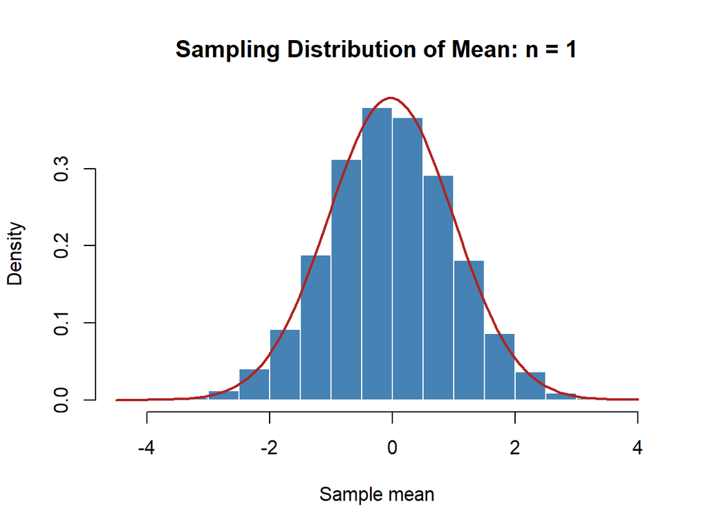

Figure 1: Illustration of normal histogram (left) and normal Q–Q plot (right) for Normal(0, 1)

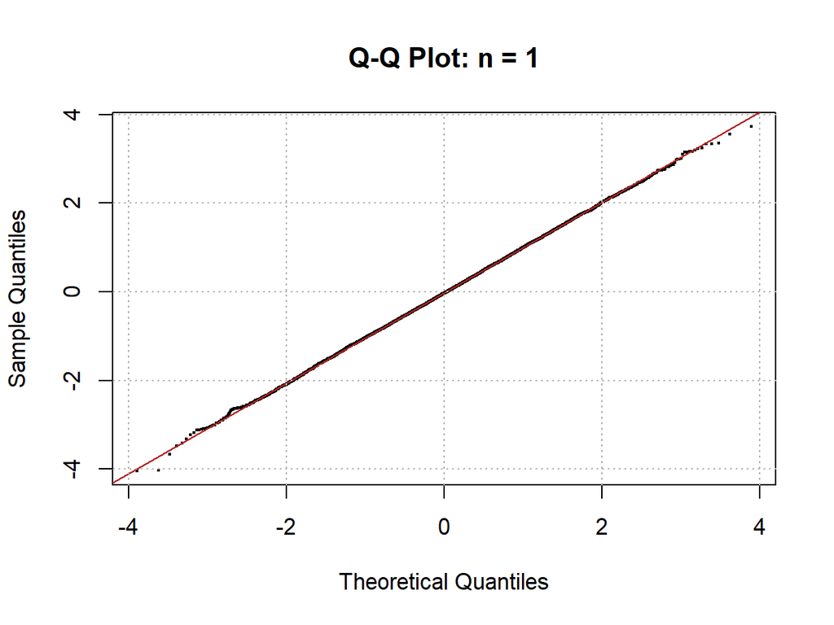

Figure 2: Illustration of normal histogram (left) and normal Q–Q plot (right) for Normal(0, 1)

```r
show_hist_qq("normal", ns = 1)
```

### 2.3.3 Formal Normality Tests

The **Shapiro–Wilk (SW) (`shapiro.test()`)** test, from the `stats` library, compares the ordered sample observations with the expected order statistics from a normal distribution and summarizes their agreement with the $W$-statistic. Values of $W$ closer to 1 indicate strong overlap with the normal bell curve and Q-Q plot. The statistic provides a numerical supplement to the visual histogram and Q–Q plot.

Because this function accepts no more than 5,000 observations, a random sample of up to 5,000 simulated sample means was selected without replacement using `sample()`.

The null hypothesis is that the simulated sample means come from a normal distribution. A $p$-value ≥ 0.05 indicates insufficient evidence to reject this hypothesis.

The **Lilliefors-corrected Kolmogorov–Smirnov (KS) test** (`lillie.test()`), from the `nortest` library, compares the empirical cumulative distribution function (CDF) of the simulated sample means with the CDF of a fitted normal distribution. The Lilliefors correction accounts for the fact that the normal distribution’s mean and standard deviation are estimated from the data rather than known in advance.

The $D$-statistic is the maximum absolute vertical difference between the empirical CDF and the fitted normal CDF. It summarizes the largest discrepancy but does not identify its location or cause. Therefore, a large $D$-statistic may reflect a localized deviation, such as a tail discrepancy or outlying observations, and should be interpreted alongside the histogram, Q–Q plot, and other normality diagnostics.

p-value for this test serve same function as the Shapiro–Wilk test.

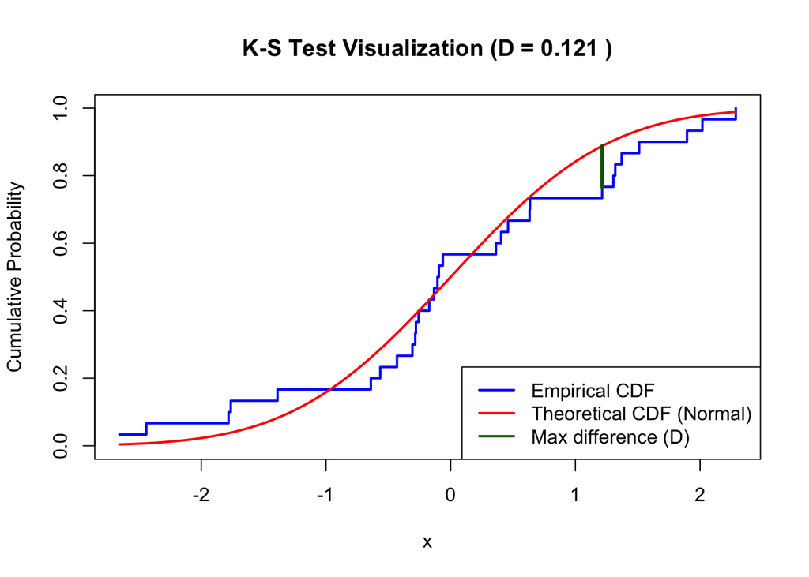

Figure 3: Illustration of the Lilliefors-corrected Kolmogorov–Smirnov test.

```r
knitr::include_graphics("images/fig-ks-test.png")
```

The **Anderson–Darling (AD) test** (`ad.test()`), from `nortest` library, also compares the empirical CDF with the fitted normal CDF, but it applies greater weight to discrepancies in the distribution tails. The $A$-statistic also outputs a single point of greatest difference.

Because the tails receive greater weight, a deviation near the tails can produce a relatively large $A$-statistic even when the center of the distribution appears approximately normal. The test is also sensitive to the large number of simulated sample means, so small departures from normality may produce small $p$-values. Therefore, the AD test was treated as reference and interpreted alongside the graphical diagnostics and other normality measures.

$p$-value for this test serve same function as the Shapiro–Wilk test.

The **D’Agostino–Pearson omnibus test(`dagoTest()`)**, from the `fBasics` library, jointly evaluates skewness and kurtosis to assess whether the simulated sample means are consistent with a normal distribution. It combines the standardized skewness and kurtosis statistics:

$$K^2 = Z_{\text{skew}}^2 + Z_{\text{kurt}}^2,$$

which approximately follows a chi-square distribution with 2 degrees of freedom under the null hypothesis of normality. Using a 95% significance level, $\chi^2_{0.95,2}=5.991.$

Because the simulation contains 10,000 sample means, the test may detect small departures from normality, including slight skewness or tail differences. For some populations, the sampling distribution’s skewness and kurtosis may converge slowly—or not converge fully—to the normal benchmarks of 0 and 3, respectively. If these deviations remain within the predefined practical tolerances, the sampling distribution may still be treated as approximately normal for this investigation, if supported by other tests.

$p$-value for this test serve same function as the Shapiro–Wilk test.

**WarningSummary notes p-values**

Because $R = 10,000$, these tests have high statistical power and may reject normality for small deviations that are not practically important. The p-values were therefore treated as supporting evidence rather than as automatic decision rules. The primary assessment used the mean, standard error, skewness, kurtosis, histogram, Q–Q plot, and consistency of the results across increasing values of $n$.

# 3 Results

## 3.1 All Statistics

The table summarizes the selected minimum sample size, $n$, for each population distribution. The selected value is the smallest tested $n$ at which most or all test satisfied the practical tolerances specified in Section 2.3.

Dependent, highly skewed, and heavy-tailed populations often became approximately normal in the center while retaining noticeable deviations in the tails. Because tail convergence generally occurs more slowly than central convergence, the selected $n$ was based on the combined evidence from the moment statistics, graphical diagnostics, and formal tests. When the tail-sensitive tests indicated departures but the remaining diagnostics supported approximate normality, the value of $n$ was retained as a practical convergence point. Stricter tail tolerances would require a larger sample size. See the individual distribution sections for more detail discussion.

```r
detail <- do.call(rbind, lapply(meta$dist, report_row))
detail$Ok <- ifelse(!is.na(detail$normal_enough) & detail$normal_enough, "✓", "")
dcols <- intersect(c("label", "n", "Mean", "Median", "SD", "Skewness", "Z_s", "Kurtosis",
                     "Z_k", stat_cols, "Ok"), names(detail))
dd <- detail[, dcols, drop = FALSE]
dd$label <- as.character(dd$label)
gt(dd) |>
  cols_label(.list = as.list(col_labels[names(col_labels) %in% names(dd)])) |>
  fmt_number(columns = any_of(c("Mean", "Median", "SD", "Skewness", "Kurtosis", "Z_s", "Z_k")),
             decimals = 3) |>
  fmt_number(columns = any_of(c("SW_W", "Lillie_D")), decimals = 4) |>
  fmt_number(columns = any_of(c("AD_A", "DP_Chi2")), decimals = 3) |>
  fmt_integer(columns = "n") |>
  sub_missing(missing_text = "—") |>
  style_gt(12)
```

Table 4: Every statistic for each population at the smallest sample size judged normal, with the normality-test statistics (W, D, A, χ²). A check mark means that row meets the normal-enough thresholds. Cauchy has no such n, so its largest tested n is shown.

| Distribution | n | Mean | Median | SD (sim. SE) | Skew | Kurt | Shapiro–Wilk W | Lilliefors D | Anderson–Darling A | D'Ag.–P. χ² | Normal enough? |
| --- | --- | --- | --- | --- | --- | --- | --- | --- | --- | --- | --- |
| Normal(0, 1) | 1 | −0.030 | −0.034 | 1.017 | −0.001 | 2.983 | 0.9998 | 0.0044 | 0.177 | 0.101 | ✓ |
| Uniform(0, 1) | 7 | 0.499 | 0.498 | 0.109 | −0.012 | 2.909 | 0.9994 | 0.0072 | 0.479 | 3.888 | ✓ |
| Six-sided die | 12 | 3.510 | 3.500 | 0.491 | −0.039 | 2.975 | 0.9972 | 0.0364 | 11.952 | 2.796 | ✓ |
| Exponential(1) | 32 | 1.001 | 0.993 | 0.177 | 0.326 | 3.096 | 0.9950 | 0.0226 | 11.721 | 172.394 | ✓ |
| Poisson(1) | 30 | 1.000 | 1.000 | 0.183 | 0.173 | 2.992 | 0.9950 | 0.0503 | 17.987 | 49.191 | ✓ |
| Small Binomial(5, 0.10) | 30 | 0.499 | 0.500 | 0.123 | 0.231 | 3.027 | 0.9898 | 0.0722 | 37.282 | 87.076 | ✓ |
| Large Binomial(20, 0.50) | 2 | 9.974 | 10.000 | 1.593 | −0.023 | 2.958 | 0.9914 | 0.0668 | 39.824 | 1.627 | ✓ |
| Cauchy(0, 1) | 1,000 | 1.642 | −0.016 | 88.229 | 70.302 | 5,864.335 | 0.0251 | 0.4326 | 3,372.717 | 35,476.641 |  |
| Age at death (bimodal) | 20 | 50.038 | 50.150 | 6.196 | −0.175 | 2.957 | 0.9982 | 0.0127 | 3.170 | 51.101 | ✓ |
| Machine failure (dependent) | 191 | 1.669 | 1.662 | 0.157 | 0.277 | 3.180 | 0.9947 | 0.0196 | 7.553 | 135.155 | ✓ |
| Basketball shots (non-identical) | 10 | 14.006 | 14.000 | 0.619 | −0.053 | 3.022 | 0.9976 | 0.0371 | 11.015 | 4.960 | ✓ |

## 3.2 Normal(0, 1)

### 3.2.1 Description

The population distribution is already normal. A small sample size is expected for CLT.

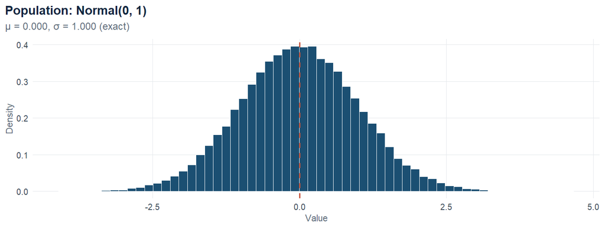

Figure 4: Population distribution for Normal(0, 1) (50,000 simulated draws). The dashed line marks the mean.

```r
plot_population("normal")
```

### 3.2.2 Convergence of the Mean, Median, Skewness and Kurtosis

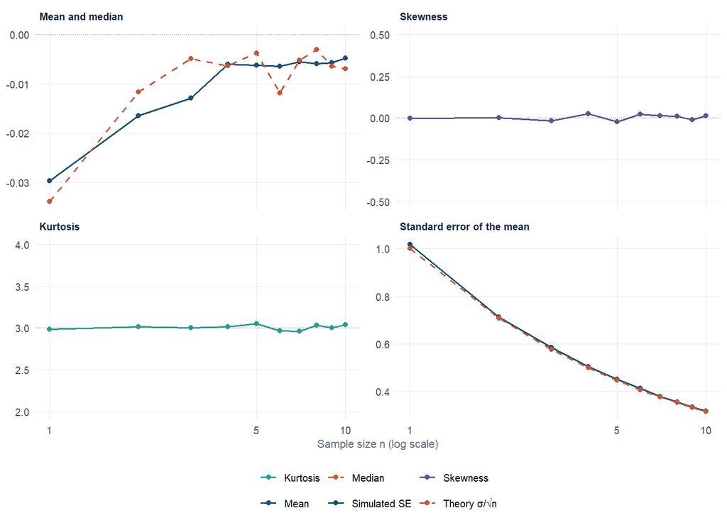

```r
plot_convergence("normal")
```

For the normal population, all evaluated moment statistics were within the predefined tolerances starting at n=1. This is expected because n = 1 is equivalent to selecting the normal population. As n increased, the statistics remained stable and showed no evidence of divergence from the normal benchmarks.

### 3.2.3 Histograms and Q–Q Plots

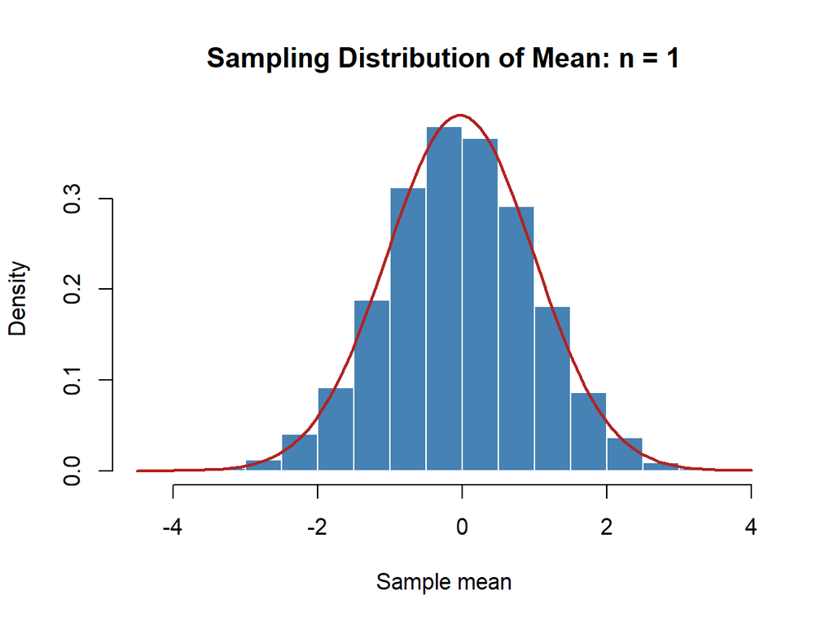

Figure 6: Histogram (left) and normal Q–Q plot (right) of the sample means at selected n.

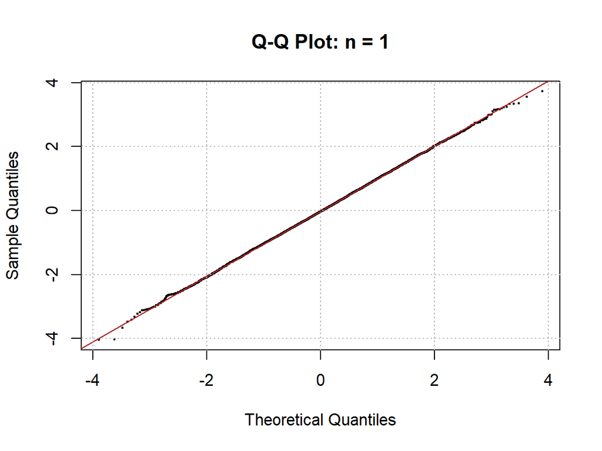

Figure 7: Histogram (left) and normal Q–Q plot (right) of the sample means at selected n.

```r
show_hist_qq("normal")
```

The histogram closely follows the fitted normal density curve. The observations also follow the Q–Q reference line, with only a few outliers at the extreme tails.

### 3.2.4 Formal Test Results

```r
stats_table("normal")
```

Table 5: Normality diagnostics for Normal(0, 1) at the selected n.

| n | Mean | SD (sim. SE) | Skew | Kurt | Shapiro–Wilk W | Shapiro–Wilk p | Lilliefors (KS) D | Lilliefors (KS) p | Anderson–Darling A | Anderson–Darling p | D'Agostino–Pearson χ² | D'Agostino–Pearson p |
| --- | --- | --- | --- | --- | --- | --- | --- | --- | --- | --- | --- | --- |
| 1 | −0.030 | 1.017 | −0.001 | 2.983 | 0.9998 | 0.846 | 0.0044 | 0.902 | 0.177 | 0.922 | 0.101 | 0.951 |
| 5 | −0.006 | 0.453 | −0.024 | 3.049 | 0.9997 | 0.771 | 0.0050 | 0.785 | 0.251 | 0.743 | 1.996 | 0.369 |

All tests produced statistic values within the tolerances specified in Section 2.3. Also, $p$-values ≥ 0.05, and thus there was insufficient evidence to reject the null hypothesis of normality.

**NoteNormal distribution: n = 1**

## 3.3 Uniform(0, 1)

### 3.3.1 Description

The population distribution is continuous and already symmetrical. A relatively low n is expected for convergence.

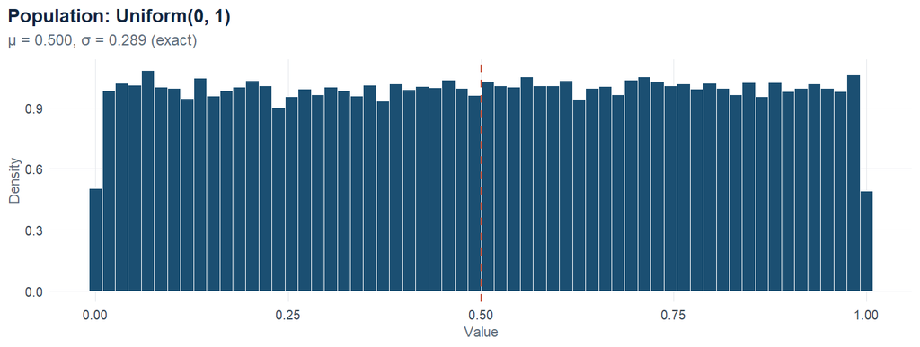

Figure 8: Population distribution for Uniform(0, 1) (50,000 simulated draws). The dashed line marks the mean.

```r
plot_population("uniform")
```

### 3.3.2 Convergence of the Mean, Median, Skewness and Kurtosis

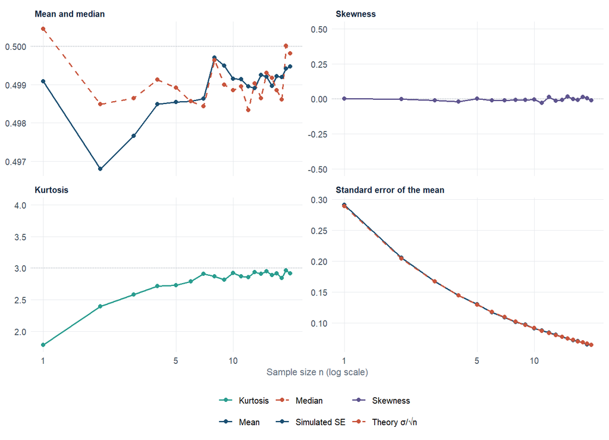

```r
plot_convergence("uniform")
```

The moment statistics are within the tolerance as soon as n = 2, and they continue to stabilize as n increases.

### 3.3.3 Histograms and Q–Q Plots

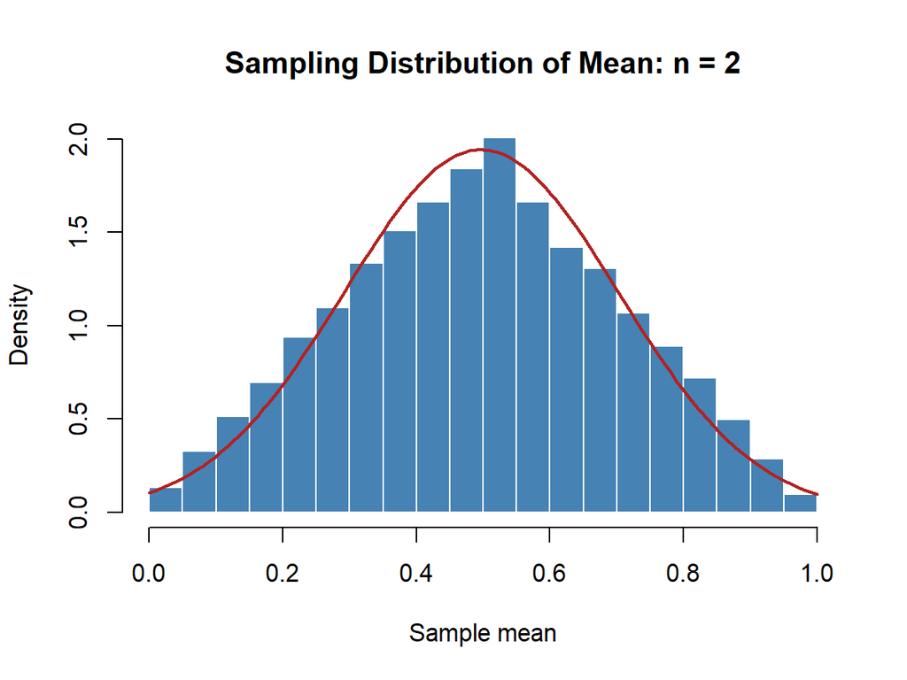

Figure 10: Histogram (left) and normal Q–Q plot (right) of the sample means at selected n.

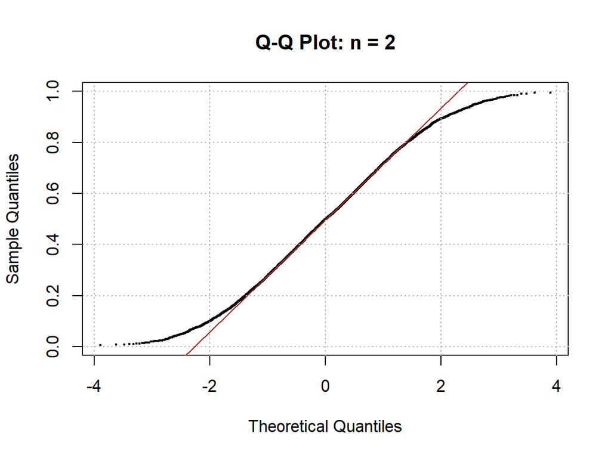

Figure 11: Histogram (left) and normal Q–Q plot (right) of the sample means at selected n.

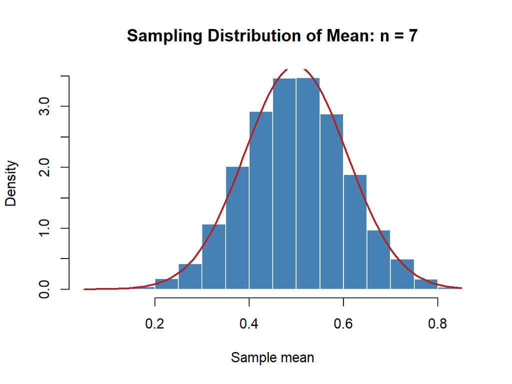

Figure 12: Histogram (left) and normal Q–Q plot (right) of the sample means at selected n.

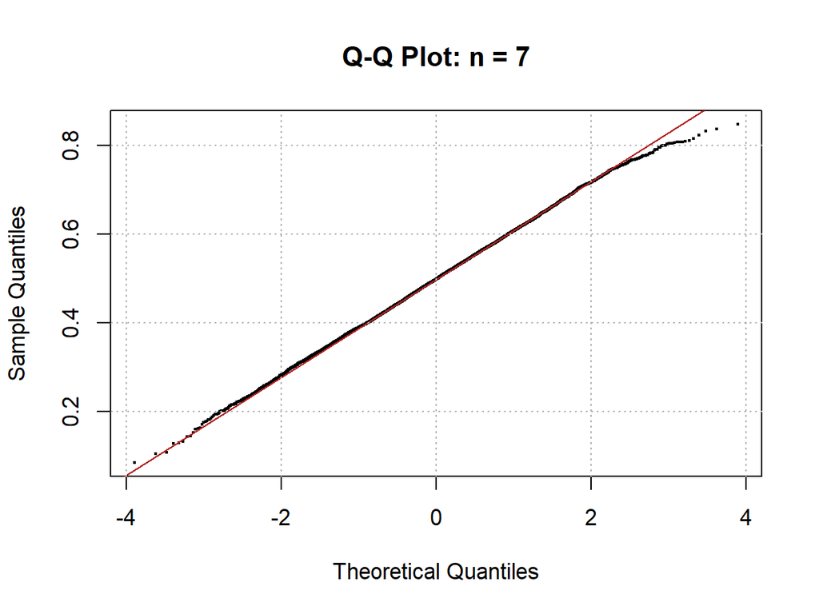

Figure 13: Histogram (left) and normal Q–Q plot (right) of the sample means at selected n.

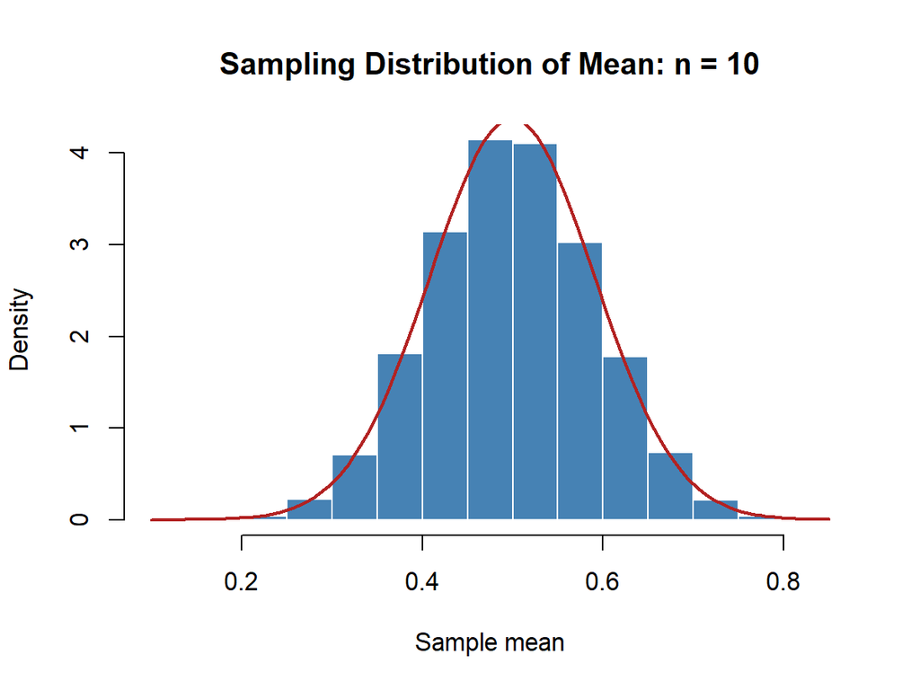

Figure 14: Histogram (left) and normal Q–Q plot (right) of the sample means at selected n.

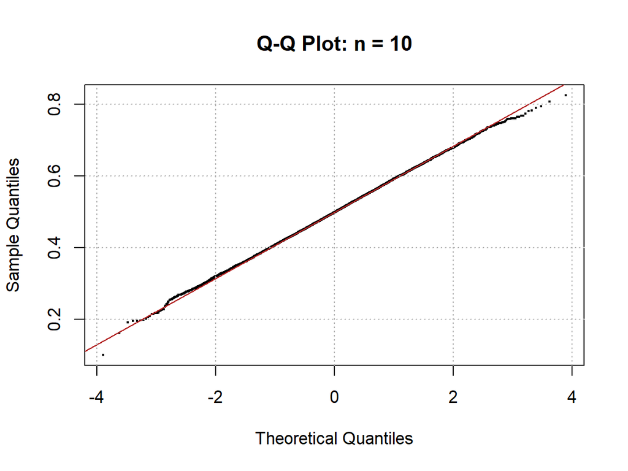

Figure 15: Histogram (left) and normal Q–Q plot (right) of the sample means at selected n.

```r
show_hist_qq("uniform")
```

At n=2, the Q–Q plot still shows noticeable curvature away from the reference line. By 7 < n < 10, the Q–Q points follow the reference line more closely, a better agreement with normality, minus the slight deviation at the very right tail end.